# Practical Machine Learning Project Assignment

Balti Boix

7 de noviembre de 2015

### The Weight Lifting Exercises Dataset Description

This human activity recognition research has focused on “how (well)” an activity was performed by the wearer.

Six young health participants were asked to perform one set of 10 repetitions of the Unilateral Dumbbell Biceps Curl in five different fashions:

```
  exactly according to the specification (Class A),
  throwing the elbows to the front (Class B),
  lifting the dumbbell only halfway (Class C),
  lowering the dumbbell only halfway (Class D) and
  throwing the hips to the front (Class E).
```

Class A corresponds to the specified execution of the exercise, while the other 4 classes correspond to common mistakes.

### Source

Qualitative Activity Recognition of Weight Lifting Exercises Velloso, E.; Bulling, A.; Gellersen, H.; Ugulino, W.; Fuks, H. Qualitative Activity Recognition of Weight Lifting Exercises. Proceedings of 4th Augmented Human (AH) International Conference in cooperation with ACM SIGCHI (Augmented Human’13) . Stuttgart, Germany: ACM SIGCHI, 2013. Cited by 15 (Google Scholar)

Read more: http://groupware.les.inf.puc-rio.br/work.jsf?p1=11201#ixzz3qpR558zc http://groupware.les.inf.puc-rio.br/har

### Goal

The goal of your project is to predict the manner in which they did the exercise. This is the “classe” variable in the training set. You may use any of the other variables to predict with. You should create a report describing how you built your model, how you used cross validation, what you think the expected out of sample error is, and why you made the choices you did. You will also use your prediction model to predict 20 different test cases.

### Discussion of results

I have not been able to find a description of the data set variables on the Internet. I can guess that it consist in time series grouped in windows that should be analized together. But as the test data correspond to independent rows I have decided to consider the same in the training set. A summary of the training data is on the appendix.

If we want to find a model that can be used to check if a person is doing his/her exercises correctly seems clear that variables like user_name or date should not be used. As it seems that the test data has been extracted from the time series these variables are very significant in the models. To show it **fit1** model uses only this type of information (cols 2:7) and gets a perfect match!

At the three fits a perfect match is attained on the training data. The estimated out-of-sample error is very low.

The prediction over the test data give the same results except for **fit** in the third row (incorrect in submission part of the assigment and been correct the result with **fit0** and **fit1**).

A facet plot of the 20 most important variable of **fit0** are shown on the appendix

#### Loading and Processing the Raw Data

The training and test csv files are downloaded from the Course Web into R working directory. From there are read directly into Data frames using the file header as column names.

```r
download.file("https://d396qusza40orc.cloudfront.net/predmachlearn/pml-training.csv", "pml-training.csv")
download.file("https://d396qusza40orc.cloudfront.net/predmachlearn/pml-testing.csv", "pml-testing.csv")
Origtraindf<-read.table("pml-training.csv", sep = ",", header = TRUE, na.strings = c("NA", "", "#DIV/0!"))
Origtestdf<-read.table("pml-testing.csv", sep = ",", header = TRUE, na.strings = c("NA", "", "#DIV/0!"))
```

R Packages used for analysis and plotting are loaded if required. The number of rows and columns are shown.

```r
require(dplyr, quietly = TRUE)
require(ggplot2, quietly = TRUE)
require(caret, quietly = TRUE)
require(rpart, quietly = TRUE)
require(randomForest, quietly = TRUE)
require(gbm, quietly = TRUE)
require(foreach, quietly = TRUE)
require(doParallel, quietly = TRUE)
require(tidyr, quietly = TRUE)

if (file.exists("my_fit.rda") & !exists("fit")) load("my_fit.rda")
if (file.exists("my_fit0.rda") & !exists("fit0")) load("my_fit0.rda")
if (file.exists("my_fit1.rda") & !exists("fit1")) load("my_fit1.rda")

data.frame(dim(Origtraindf), dim(Origtestdf))
```

```
##   dim.Origtraindf. dim.Origtestdf.
## 1            19622              20
## 2              160             160
```

First obvious cols like X (equivalent a number of row), user name, time_stamps and windows are removed.  
Then the cols (variables) that have more than 80% of values different from NA are determined and selected. Or what is the same, the cols with more tan 80% of NA’s are removed.

```r
filtervars<-names(Origtraindf)
filtervars<-filtervars[8:length(filtervars)]
traindf<-select(Origtraindf, one_of(filtervars))
filtervars<-names(traindf[, colSums(!is.na(traindf)) > 0.8*nrow(traindf)])
traindf<-select(traindf, one_of(filtervars))
```

Models **fit**, **fit0** and **fit1** are generated and the statistics are shown using the function confusionMatrix

```r
if(!exists("fit")) {
      fit<-train(classe ~ ., method= "rf", trControl = trainControl(method = "cv", number = 3),
                 preProcess="pca", data = traindf)
      save(fit, file="my_fit.rda")}

confusionMatrix(traindf$classe, predict(fit, Origtraindf))
```

```
## Confusion Matrix and Statistics
##
##           Reference
## Prediction    A    B    C    D    E
##          A 5580    0    0    0    0
##          B    0 3797    0    0    0
##          C    0    0 3422    0    0
##          D    0    0    0 3216    0
##          E    0    0    0    0 3607
##
## Overall Statistics
##
##                Accuracy : 1
##                  95% CI : (0.9998, 1)
##     No Information Rate : 0.2844
##     P-Value [Acc > NIR] : < 2.2e-16
##
##                   Kappa : 1
##  Mcnemar's Test P-Value : NA
##
## Statistics by Class:
##
##                      Class: A Class: B Class: C Class: D Class: E
## Sensitivity            1.0000   1.0000   1.0000   1.0000   1.0000
## Specificity            1.0000   1.0000   1.0000   1.0000   1.0000
## Pos Pred Value         1.0000   1.0000   1.0000   1.0000   1.0000
## Neg Pred Value         1.0000   1.0000   1.0000   1.0000   1.0000
## Prevalence             0.2844   0.1935   0.1744   0.1639   0.1838
## Detection Rate         0.2844   0.1935   0.1744   0.1639   0.1838
## Detection Prevalence   0.2844   0.1935   0.1744   0.1639   0.1838
## Balanced Accuracy      1.0000   1.0000   1.0000   1.0000   1.0000
```

```r
if(!exists("fit0")) {
      fit0<-train(classe ~ ., method= "rf", trControl = trainControl(method = "cv", number = 3),
                 data = traindf)
      save(fit0, file="my_fit0.rda")}

confusionMatrix(traindf$classe, predict(fit0, Origtraindf))
```

```
## Confusion Matrix and Statistics
##
##           Reference
## Prediction    A    B    C    D    E
##          A 5580    0    0    0    0
##          B    0 3797    0    0    0
##          C    0    0 3422    0    0
##          D    0    0    0 3216    0
##          E    0    0    0    0 3607
##
## Overall Statistics
##
##                Accuracy : 1
##                  95% CI : (0.9998, 1)
##     No Information Rate : 0.2844
##     P-Value [Acc > NIR] : < 2.2e-16
##
##                   Kappa : 1
##  Mcnemar's Test P-Value : NA
##
## Statistics by Class:
##
##                      Class: A Class: B Class: C Class: D Class: E
## Sensitivity            1.0000   1.0000   1.0000   1.0000   1.0000
## Specificity            1.0000   1.0000   1.0000   1.0000   1.0000
## Pos Pred Value         1.0000   1.0000   1.0000   1.0000   1.0000
## Neg Pred Value         1.0000   1.0000   1.0000   1.0000   1.0000
## Prevalence             0.2844   0.1935   0.1744   0.1639   0.1838
## Detection Rate         0.2844   0.1935   0.1744   0.1639   0.1838
## Detection Prevalence   0.2844   0.1935   0.1744   0.1639   0.1838
## Balanced Accuracy      1.0000   1.0000   1.0000   1.0000   1.0000
```

```r
if(!exists("fit1")) {
      traindf<- Origtraindf[,2:7]
      fit1<-train(classe ~ ., method= "rf", trControl = trainControl(method = "cv", number = 3),
                 data = traindf)
      save(fit1, file="my_fit1.rda")}

confusionMatrix(traindf$classe, predict(fit1, Origtraindf))
```

```
## Confusion Matrix and Statistics
##
##           Reference
## Prediction    A    B    C    D    E
##          A 5580    0    0    0    0
##          B    0 3797    0    0    0
##          C    0    0 3422    0    0
##          D    0    0    0 3216    0
##          E    0    0    0    0 3607
##
## Overall Statistics
##
##                Accuracy : 1
##                  95% CI : (0.9998, 1)
##     No Information Rate : 0.2844
##     P-Value [Acc > NIR] : < 2.2e-16
##
##                   Kappa : 1
##  Mcnemar's Test P-Value : NA
##
## Statistics by Class:
##
##                      Class: A Class: B Class: C Class: D Class: E
## Sensitivity            1.0000   1.0000   1.0000   1.0000   1.0000
## Specificity            1.0000   1.0000   1.0000   1.0000   1.0000
## Pos Pred Value         1.0000   1.0000   1.0000   1.0000   1.0000
## Neg Pred Value         1.0000   1.0000   1.0000   1.0000   1.0000
## Prevalence             0.2844   0.1935   0.1744   0.1639   0.1838
## Detection Rate         0.2844   0.1935   0.1744   0.1639   0.1838
## Detection Prevalence   0.2844   0.1935   0.1744   0.1639   0.1838
## Balanced Accuracy      1.0000   1.0000   1.0000   1.0000   1.0000
```

From every model we extract the accuracy of the three folders used for resampling. The out-of-sample error is estimated from the mean accuracy.

```r
accufit<-data.frame(Fit=fit$resample$Accuracy, Fit0=fit0$resample$Accuracy,
                    Fit1=fit1$resample$Accuracy)
accufit
```

```
##         Fit      Fit0      Fit1
## 1 0.9767620 0.9932732 0.9963308
## 2 0.9709525 0.9922030 0.9801223
## 3 0.9762997 0.9938838 0.9841003
```

```r
summarize(accufit, oos=round(1-mean(Fit),4), oos0=round(1-mean(Fit0),4),
          oos1=round(1-mean(Fit1),4))
```

```
##      oos   oos0   oos1
## 1 0.0253 0.0069 0.0131
```

Applying the models to the test data and grouped and shown in the **resdf** data frame.

```r
resdf<-data.frame(classe0=predict(fit0, Origtestdf), classe=predict(fit, Origtestdf), classe1=predict(fit1, Origtestdf))
resdf
```

```
##    classe0 classe classe1
## 1        B      B       B
## 2        A      A       A
## 3        B      A       B
## 4        A      A       A
## 5        A      A       A
## 6        E      E       E
## 7        D      D       D
## 8        B      B       B
## 9        A      A       A
## 10       A      A       A
## 11       B      B       B
## 12       C      C       C
## 13       B      B       B
## 14       A      A       A
## 15       E      E       E
## 16       E      E       E
## 17       A      A       A
## 18       B      B       B
## 19       B      B       B
## 20       B      B       B
```

The files for the submission assignment are printed with the function suggested in the Coursera project page.

```r
pml_write_files = function(x){
  n = length(x)
  for(i in 1:n){
    filename = paste0("problem_id_",i,".txt")
    write.table(x[i],file=filename,quote=FALSE,row.names=FALSE,col.names=FALSE)
  }
}

pml_write_files(as.vector(resdf$classe0))
```

### Appendix

A summary of the training data set is presented.

```r
summary(Origtraindf)
```

```
##        X            user_name    raw_timestamp_part_1 raw_timestamp_part_2
##  Min.   :    1   adelmo  :3892   Min.   :1.322e+09    Min.   :   294
##  1st Qu.: 4906   carlitos:3112   1st Qu.:1.323e+09    1st Qu.:252912
##  Median : 9812   charles :3536   Median :1.323e+09    Median :496380
##  Mean   : 9812   eurico  :3070   Mean   :1.323e+09    Mean   :500656
##  3rd Qu.:14717   jeremy  :3402   3rd Qu.:1.323e+09    3rd Qu.:751891
##  Max.   :19622   pedro   :2610   Max.   :1.323e+09    Max.   :998801
##
##           cvtd_timestamp  new_window    num_window      roll_belt
##  28/11/2011 14:14: 1498   no :19216   Min.   :  1.0   Min.   :-28.90
##  05/12/2011 11:24: 1497   yes:  406   1st Qu.:222.0   1st Qu.:  1.10
##  30/11/2011 17:11: 1440               Median :424.0   Median :113.00
##  05/12/2011 11:25: 1425               Mean   :430.6   Mean   : 64.41
##  02/12/2011 14:57: 1380               3rd Qu.:644.0   3rd Qu.:123.00
##  02/12/2011 13:34: 1375               Max.   :864.0   Max.   :162.00
##  (Other)         :11007
##    pitch_belt          yaw_belt       total_accel_belt kurtosis_roll_belt
##  Min.   :-55.8000   Min.   :-180.00   Min.   : 0.00    Min.   :-2.121
##  1st Qu.:  1.7600   1st Qu.: -88.30   1st Qu.: 3.00    1st Qu.:-1.329
##  Median :  5.2800   Median : -13.00   Median :17.00    Median :-0.899
##  Mean   :  0.3053   Mean   : -11.21   Mean   :11.31    Mean   :-0.220
##  3rd Qu.: 14.9000   3rd Qu.:  12.90   3rd Qu.:18.00    3rd Qu.:-0.219
##  Max.   : 60.3000   Max.   : 179.00   Max.   :29.00    Max.   :33.000
##                                                        NA's   :19226
##  kurtosis_picth_belt kurtosis_yaw_belt skewness_roll_belt
##  Min.   :-2.190      Mode:logical      Min.   :-5.745
##  1st Qu.:-1.107      NA's:19622        1st Qu.:-0.444
##  Median :-0.151                        Median : 0.000
##  Mean   : 4.334                        Mean   :-0.026
##  3rd Qu.: 3.178                        3rd Qu.: 0.417
##  Max.   :58.000                        Max.   : 3.595
##  NA's   :19248                         NA's   :19225
##  skewness_roll_belt.1 skewness_yaw_belt max_roll_belt     max_picth_belt
##  Min.   :-7.616       Mode:logical      Min.   :-94.300   Min.   : 3.00
##  1st Qu.:-1.114       NA's:19622        1st Qu.:-88.000   1st Qu.: 5.00
##  Median :-0.068                         Median : -5.100   Median :18.00
##  Mean   :-0.296                         Mean   : -6.667   Mean   :12.92
##  3rd Qu.: 0.661                         3rd Qu.: 18.500   3rd Qu.:19.00
##  Max.   : 7.348                         Max.   :180.000   Max.   :30.00
##  NA's   :19248                          NA's   :19216     NA's   :19216
```

[output cut: 313 more lines]

```
##  Min.   :-446.00   Min.   :-1280.0   Min.   :-896.0   Min.   :-973.0
##  1st Qu.:-182.00   1st Qu.: -616.0   1st Qu.:   2.0   1st Qu.: 191.0
##  Median : -39.00   Median : -378.0   Median : 591.0   Median : 511.0
##  Mean   : -55.29   Mean   : -312.6   Mean   : 380.1   Mean   : 393.6
##  3rd Qu.:  26.00   3rd Qu.:  -73.0   3rd Qu.: 737.0   3rd Qu.: 653.0
##  Max.   : 291.00   Max.   :  672.0   Max.   :1480.0   Max.   :1090.0
##
##  classe
##  A:5580
##  B:3797
##  C:3422
##  D:3216
##  E:3607
##
##
```

A facet plot of the 20 most important variable of **fit0**

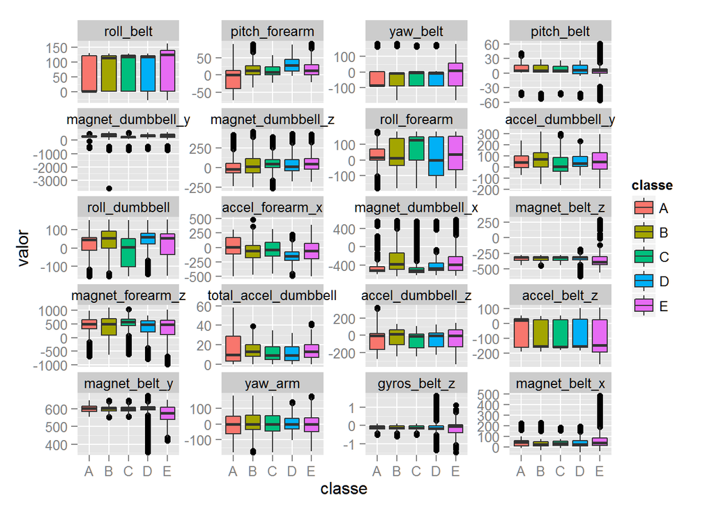

```r
vi<-varImp(fit0)
df<-data.frame(name=rownames(vi$importance), imp=vi$importance$Overall)
df<-arrange(df, -imp)
plotdf<-select(Origtraindf, one_of(c("classe", as.character(df$name[1:20]))))
plotdf<-gather(plotdf, key=clave, value=valor, -classe)
plotdf$clave<-factor(plotdf$clave, levels=as.character(df$name[1:20]))
p<-ggplot(plotdf, aes(x=classe, y=valor, fill=classe))
p<-p + geom_boxplot()
p<-p + facet_wrap(~ clave, scales="free_y", ncol=4)
print(p)
```